# Kaiser Stroke and Dementia Validation

2024-08-09

## Goal

This notebook performs the survival analysis of the simulated Kaiser population. The results from the simulation are compared with the relevant publications (Kent2021 and Kent2023).

## Stroke-free probability

The stroke-free probability as a function of time in the simulated Kaiser population is qualitatively similar with Figure 1 in the publication (Kent2021). There are quantitative differences however, for example, in Kent2021 after 10 years after image scan, the stroke-free probability for the population with SBI and WMH was about 0.7 whereas in the simulated Kaiser population the same probability was about 0.9. It is interesting though that another feature is well reproduced in the simulation: the probability curves of SBI only and WMH only both in Kent2021 and the simulation are closer to each other compared to the no SBI or WMH or the SBI and WMH probability curves.

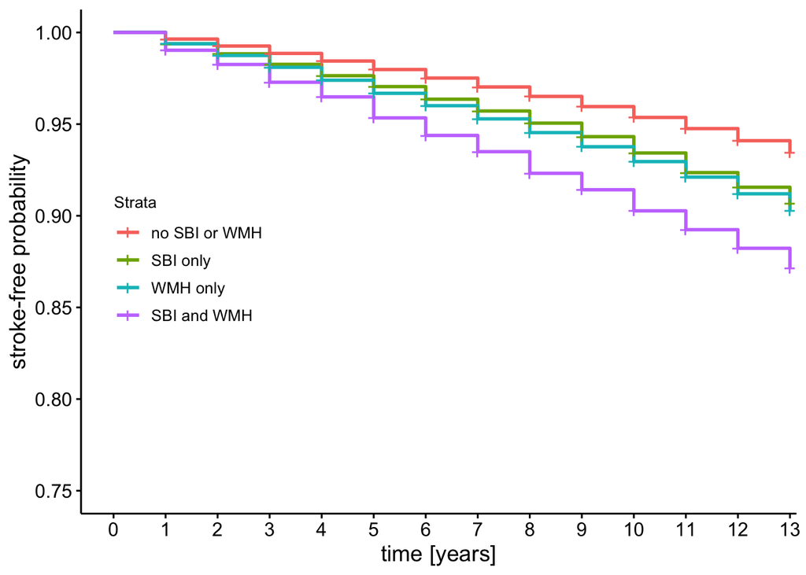

## Dementia-free probability

Overall, the simulation reproduces qualitatively at least the results shown in Figure 2 in Kent2023. Quantitatively however there are significant differences.

The MRI No group had the highest dementia-free probability in both the simulation and Kent2023. The CT No group and MRI Mild group had probabilities that were close but not as close as Kent2023. The MRI Moderate group had probabilities a bit higher than the MRI Unknown group, whereas the opposite was true in Kent2023. The CT Unknown, CT Moderate and CT Severe had probabilities in the same order in the simulation and Kent2023.

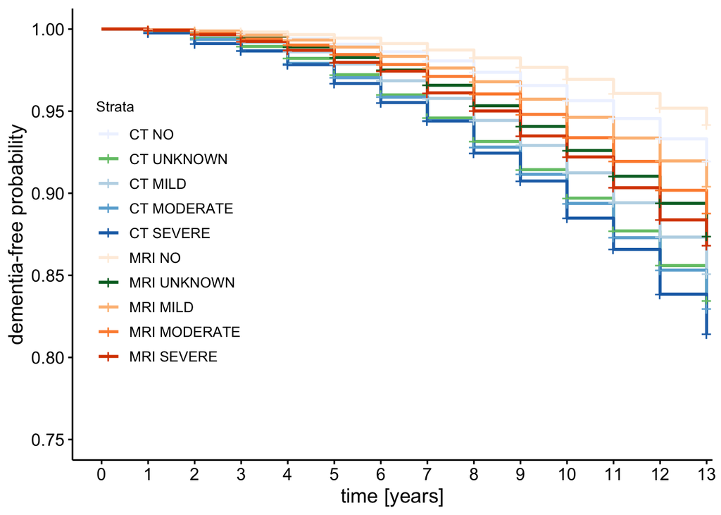